# Calculating expected edges

Jason T. Serviss

2019-07-05

```r
packages <- c("CIMseq", "tidyverse")
purrr::walk(packages, library, character.only = TRUE)
rm(packages)

load('../../../inst/analysis/MGA.analysis_SI20/data/CIMseqData.rda')
load('../../../inst/analysis/MGA.analysis_SI20/data/sObj.rda')

#there are 2 cells that were classified as colon but sorted as SI. These have to
#be removed manually
c <- getData(cObjSng, "classification")
s <- names(c[c %in% c("8", "13")])
i <- which(colnames(getData(cObjSng, "counts")) %in% s)
cObjSng <- CIMseqSinglets(
  getData(cObjSng, "counts")[, -i],
  getData(cObjSng, "counts.ercc")[, -i],
  getData(cObjSng, "dim.red")[-i, ],
  getData(cObjSng, "classification")[-i]
)

#rename classes
renameClasses <- function(class) {
  case_when(
    class == "3" ~ "SI.Lgr5+",
    class == "4" ~ "SI.Lgr5+.Mki67+",
    class == "9" ~ "SI.Goblet",
    class == "11" ~ "SI.TA.late",
    class == "12" ~ "SI.TA.early",
    class == "14" ~ "Enteroendocrine",
    class == "15" ~ "Tufft",
    class == "16" ~ "SI.Enterocytes",
    class == "17" ~ "SI.Paneth",
    class == "19" ~ "Blood",
    TRUE ~ "error"
  )
}

cOrder <- c(
  "SI.Goblet", "SI.Paneth", "SI.Lgr5+", "SI.Lgr5+.Mki67+", "SI.TA.early", "SI.TA.late", "SI.Enterocytes",
  "Enteroendocrine", "Tufft", "Blood"
)

getData(cObjSng, "classification") <- renameClasses(getData(cObjSng, "classification"))
fractions <- getData(sObj, "fractions")
fractions <- fractions[, !colnames(fractions) %in% c("8", "13")]
colnames(fractions) <- renameClasses(colnames(fractions))
sObj@fractions <- fractions

#FUNCTIONS
singleModel <- function(classes) {
  u.classes <- unique(classes)
  classFreq <- c(table(classes))[u.classes]
  dat <- lapply(1:length(u.classes), function(i) {
    curr.class <- u.classes[i]
    other.classes <- u.classes[u.classes != curr.class]
    curr.val <- as.numeric(classFreq[i])
    other.val <- c(classFreq[names(classFreq) != curr.class]) / sum(c(classFreq[names(classFreq) != curr.class]))
    partners <- rep(other.classes, round(curr.val * other.val[other.classes])) #i think the round here is throwing off the values
    data.frame(
      from = rep(curr.class, length(partners)), to = partners,
      stringsAsFactors = FALSE
    )
  })
  grid <- Reduce(rbind, dat)
  grid
}
```

The goal here is to find an accurate way to calculate the expected edges between two cell types based on their frequency in the singlet data. Once an accurate background model of the expected edges can be developed, a p-value can be calculated based on the observed and expected values. We assume that in a background model the connections between any two cell types should be proportional to the frequency of those cell types. Therefore, the expected edges can be calculated in the following manner:

1. Estimate the number of edges from each cell type to all other cell types based on the frequency of the cell types in the singlet data.
2. Estimate the relative proportion of each edge type.
3. Calculate the absolute number of expected edges by multiplying the total number of edges, derived from the deconvolution results, by the relative proportion of each edge type.

```r
test <- c("A", "A", "A", "A", "A", "A", "B", "B", "B", "B", "B", "B",
"B", "B", "B", "B", "B", "B", "C", "C", "C", "C", "C", "C", "C",
"C", "C", "C", "D", "D", "D", "D", "D", "D", "D", "D", "D", "D",
"D", "D", "D", "D", "D", "D", "D", "D", "D", "D", "D", "D")
```

```r
table(singleModel(test))
```

```
##     to
## from A B C D
##    A 0 2 1 3
##    B 2 0 3 7
##    C 2 3 0 6
##    D 5 9 8 0
```

To complete 2., we divide the absolute edge numbers by the sum of all edges which gives us the relative frequency of the edge types.

In an actual example, we could then use these relative frequencies and multiply them by the total edges detected in the deconvolution to achieve step 3. from above. This would give us the absolute number of expected edges in the background model. Subsequently using the Poisson distribution with the expected edges (lambda) vs. the observed deconvolution edges, we can calculate the proability of observing the connections reported by the deconvolution.

It is important to note that, we do not expect the expected edges to be mirrored in both directions, i.e. expected edges for cell type A to cell type B are not equal to expected edges from cell type B to cell type A. This is true in all cases where there are an unequal number of singlets representing the two cell types. If we imagine a scenerio where one cell type with a low frequency connects to another cell type with a high frequency. We expect that the number of edges from the small frequency cell type to the high frequency cell type be lower than the number of edges connecting the high frequency cell type to the low frequency cell type based on the calculations 1-3. We can see an example of in the mouse small intestine data below:

```r
edgeStats <- calculateEdgeStats(sObj, cObjSng, cObjMul)
edgeStats <- as_tibble(edgeStats[, 1:3])

# Calculate the total number of edges in the dataset
total.edges <- sum(pull(edgeStats, weight))
classes <- getData(cObjSng, "classification")

#model the tissue connections by assigning the proportional edges for each class
#to each other class based on the class frequency.
grid <- singleModel(classes)
conn.vec <- paste(grid[, 1], grid[, 2], sep = "--")

#randomly assign the edges to the tissue model n times
iterations <- 1000
base.seed <- 5354676
perms <- lapply(1:iterations, function(i) {
  set.seed(base.seed + i)
  idx <- sample(1:length(conn.vec), total.edges, replace = TRUE)
  count <- as.data.frame(table(conn.vec[idx]))
  set_names(count, c("connection", paste0("iter", i)))
})

#reformat results
res <- Reduce(function(x, y) merge(x, y, by = "connection", all = TRUE), perms)
rownames(res) <- res$connection
res$connection <- NULL
res <- as.matrix(res)
res[is.na(res)] <- 0

#calculate the mean number of edges per connection accross each random edge
#allocation
rm <- rowMeans(res)
expected <- res %>%
  matrix_to_tibble("connection") %>%
  separate(connection, into = c("from", "to"), sep = "--") %>%
  nest(-from, -to) %>%
  mutate(data = map(data, as.numeric)) %>%
  mutate(expected.perm = rm)

#here you need to make sure all combinations are present
allCmbs <- expand.grid(from = unique(classes), to = unique(classes), stringsAsFactors = FALSE)
allCmbs <- allCmbs[allCmbs[, 1] != allCmbs[, 2], ]
expected <- merge(allCmbs, expected, by = c("from", "to"), all = TRUE)
expected[is.na(expected$data), "data"] <- NA
expected[is.na(expected$expected.perm), "expected.perm"] <- 0

#look at e.g. Blood - SI.Lgr5+ connections, the lowest and highest
#frequency cell types
expected[expected$from %in% c("Blood", "SI.Lgr5+") & expected$to %in% c("Blood", "SI.Lgr5+"), c("from", "to", "expected.perm")]
```

```
##        from       to expected.perm
## 4     Blood SI.Lgr5+         2.214
## 37 SI.Lgr5+    Blood         3.436
```

```r
edgeStats <- inner_join(edgeStats, expected, by = c("from", "to"))
```

We continue with the mouse small intestine data to demonstrate the calculation using real data. We perform the analysis in a step wise manner by first generating the tissue connection model. We then randomly distribute the total edges (discovered by the deconvolution) to the model 1000 times and look at the distribution of the edges for each edge type.

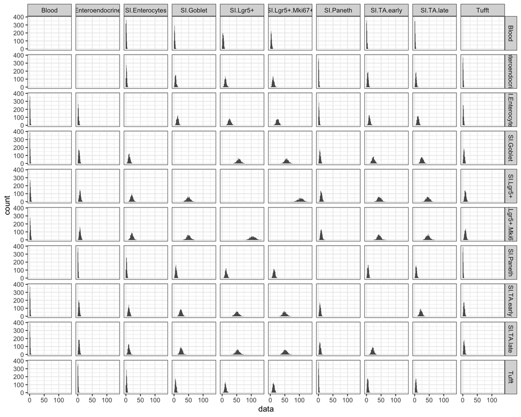

```r
#This may give Warning message: Removed 6 rows containing non-finite values
#(stat_bin). This is expected and ok to ignore.
expected %>%
  unnest() %>%
  ggplot() +
  geom_histogram(aes(data), binwidth = 1) +
  facet_grid(to~from) +
  scale_fill_manual(values = col40()) +
  theme_bw()
```

The results clearly show that the distribution of the edges for each edge type are approximatley Poisson distributed. Now that we have examined the distribution of the expected edges in the tissue model, we calculate the mean value to get one expected edges value per edge type. Then, we can directly calculate the number of expected edges, based on steps 1-3 above, and compare these with the randomly allocated edge results.

```r
#calculate expected without permutation
# class.freq <- c(table(classes))
# allProbs <- expand.grid(from = names(class.freq), to = names(class.freq), stringsAsFactors = FALSE) %>%
#   filter(from != to) %>%
#   mutate(edges = map2_dbl(from, to, function(f, t) {
#     abs <- class.freq[names(class.freq) != t]
#     rel <- abs / sum(abs)
#     as.numeric(rel[f]) * class.freq[t]
#   })) %>%
#   mutate(rel = edges / sum(edges)) %>%
#   mutate(expected = total.edges * rel)
#
# edgeStats <- mutate(edgeStats, expected.edges.calculated = map2_dbl(from, to, function(f, t) {
#     allProbs[allProbs$from == f & allProbs$to == t, "expected"]
#   }))
# edgeStats$p.pois <- ppois(q = edgeStats$weight, lambda = edgeStats$expected.edges.calculated, lower.tail = FALSE)



mat <- getData(sObj, "fractions")
class.freq <- colSums(mat)
names(class.freq) <- colnames(mat)

.f1 <- function(f, d) {
    total.out <- sum(d$weight)
    freq <- class.freq[d$to]
    rel <- freq / sum(freq)
    total.out * rel
  }

edgeStats <- edgeStats %>%
  nest(-from) %>%
  mutate(expected.edges.calculated = map2(from, data, ~.f1(.x, .y))) %>%
  unnest()

edgeStats$pval <- sapply(1:nrow(edgeStats), function(i) {
      phyper(
        q = edgeStats$weight[i],
        m = class.freq[edgeStats$to[i]],
        n = sum(class.freq) - class.freq[edgeStats$to[i]],
        k = sum(edgeStats$weight[edgeStats$from == edgeStats$from[i]]),
        lower.tail = FALSE)
 })
edgeStats$pval <- p.adjust(edgeStats$pval, 'fdr')
```

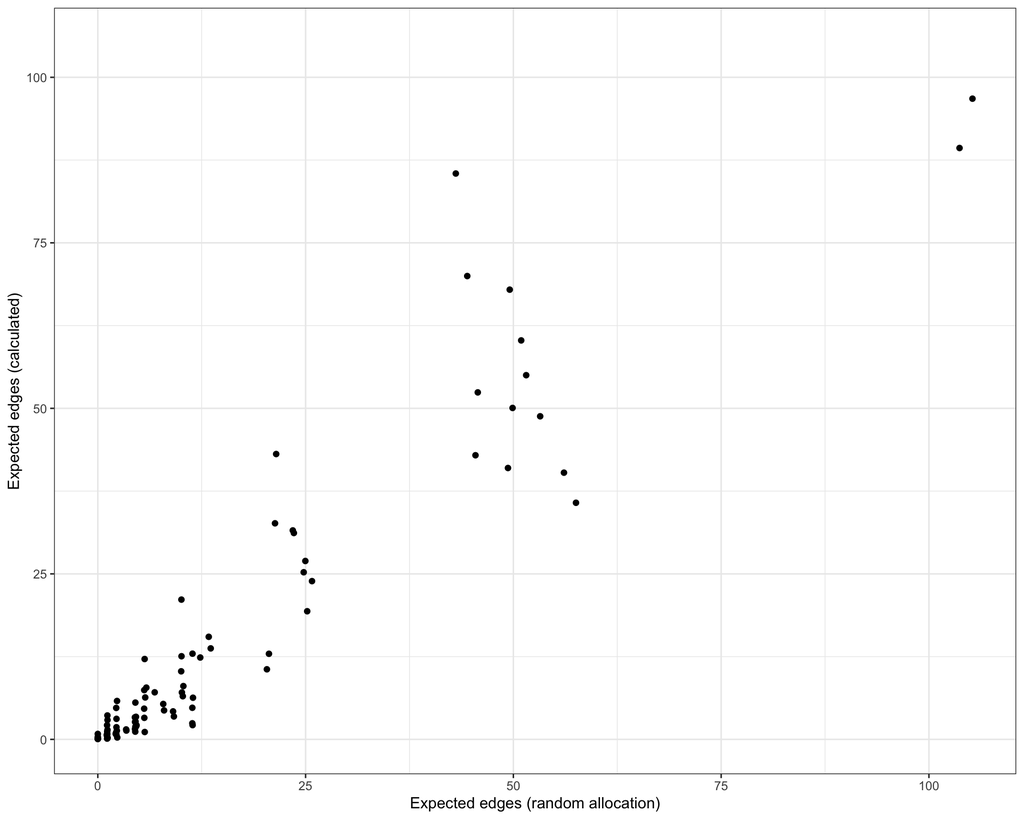

```r
edgeStats %>%
  ggplot() +
  geom_point(aes(expected.perm, expected.edges.calculated)) +
  theme_bw() +
  labs(x = "Expected edges (random allocation)", y = "Expected edges (calculated)") +
  scale_x_continuous(limits = range(c(edgeStats$expected.perm, edgeStats$expected.edges.calculated))) +
  scale_y_continuous(limits = range(c(edgeStats$expected.perm, edgeStats$expected.edges.calculated)))
```

We observe a reasonably linear relationship between the expected edges calculated using the two different methods. Most of the variation between these two methods, most likely stems from the need for a rounding step in the random allocation which is not present in the direct calculation.

Finally, we can calculate the p-value based on the deconvolution observed edge weights and the calculated expected edge values.

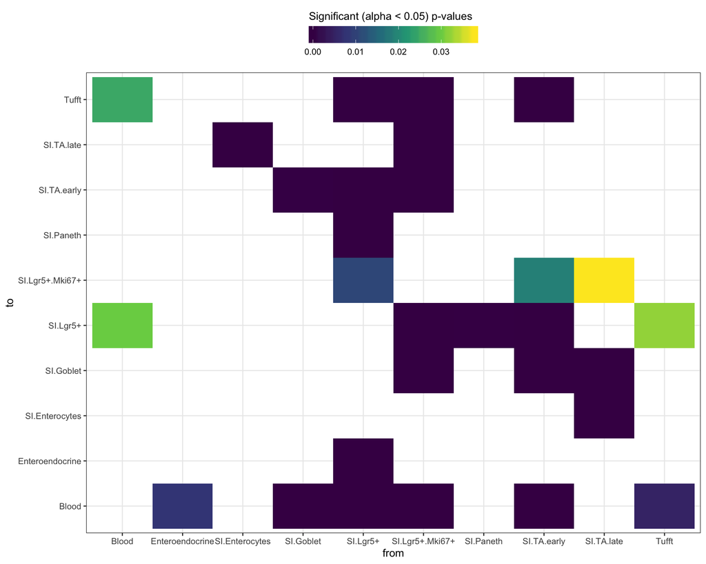

```r
# nsig <- sum(pull(edgeStats, pval) < 0.05)
# cols <- viridis::viridis(nsig + 1)
# pdata <- edgeStats %>%
#   mutate(significant = if_else(pval < 0.05, TRUE, FALSE)) %>%
#   mutate(idx = ntile(-pval, nrow(.))) %>%
#   mutate(idx = idx - max(idx[pval > 0.05])) %>%
#   mutate(idx = if_else(significant, idx + 1, 1)) %>%
#   mutate(col = cols[idx]) %>%
#   mutate(col = if_else(significant, col, "grey90"))
#
# pdata %>%
#   arrange(pval) %>%
#   mutate(col = parse_factor(col, levels = unique(col))) %>%
#   ggplot() +
#   geom_tile(aes(from, to, fill = col)) +
#   scale_fill_identity(
#     "p-value", guide = "legend",
#     labels = c(format(sort(filter(pdata, significant)$pval), digits = 2, scientific = TRUE), "n.s.")) +
#   theme_bw() +
#   theme(
#     axis.text.x = element_text(angle = 90),
#     legend.position = "top"
#   ) +
#   guides(fill = guide_legend(nrow = 3))

edgeStats %>%
  filter(pval < 0.05) %>%
  ggplot() +
  geom_tile(aes(from, to, fill = pval)) +
  scale_fill_viridis_c("Significant (alpha < 0.05) p-values") +
  theme_bw() +
  theme(legend.position = "top") +
  guides(fill = guide_colourbar(title.position = "top", title.hjust = 0.05, barwidth = 12))
```